# Analysis of Severe Weather Events on Public Health and Economy for Communities and Municipalities in the United States

Kaushik Sivasankaran

8/16/2020

## Synopsis

Storms and other severe events can cause both public health and economic problems for communities and municipalities in the United States of America. This analysis involves exploring the U.S. National Oceanic and Atmospheric Administration’s (NOAA) storm database to determine which types of severe events are most harmful to population health and have the greatest adverse econmic impact in the United States. This analysis will use a database that comprises details of severe weather events from 1950 ranging till November 2011.

## Data Processing

First, the data required to perform the analysis needs to be extracted.

After downloading the data from the course project website into the R project directory, the next step is to read in the *csv.bz2* zip file.

```r
storm_data <- read.csv(file = "repdata_data_StormData.csv.bz2", header = TRUE, sep = ",", as.is = TRUE)
```

### Extracting the required data

In order to calculate the event types that are most harmful with respect to population health and economic impact, we would need to extract following data:

- EVETYPE - Event type (Ex: Tornado, Blizzard, etc.)
- Health related impacts:
  1. Fatalities - Number of deaths caused by severe events
  2. Injuries - Number of injuries caused by severe events
- Economic related impacts:
  1. PROPDMG - Property related damage
  2. PROPDMGEXP - The unit for property damage by value
  3. CROPDMG - Crop related damage
  4. CROPDMGEXP - The unit for crop damage by value

```r
#Extracting only relevant data from storms data
event_data <- storm_data[, c("EVTYPE", "FATALITIES", "INJURIES", "PROPDMG", "PROPDMGEXP", "CROPDMG", "CROPDMGEXP")]

# Checking for NA values in the new dataframe

sum(is.na(event_data))
```

```
## [1] 0
```

```r
#Sorting the data by event type to identify the top 10 event types

sort(table(event_data$EVTYPE),decreasing = TRUE)[1:10]
```

```
##
##               HAIL          TSTM WIND  THUNDERSTORM WIND            TORNADO
##             288661             219940              82563              60652
##        FLASH FLOOD              FLOOD THUNDERSTORM WINDS          HIGH WIND
##              54277              25326              20843              20212
##          LIGHTNING         HEAVY SNOW
##              15754              15708
```

```r
# Creating a new variable to store the combined event type
event_data$Event <- "OTHER"

#Group by keyword in event type
event_data$Event[grep(pattern = "HAIL", x = event_data$EVTYPE, ignore.case = TRUE)] <- "HAIL"
event_data$Event[grep(pattern = "WIND", x = event_data$EVTYPE, ignore.case = TRUE)] <- "WIND"
event_data$Event[grep(pattern = "SNOW", x = event_data$EVTYPE, ignore.case = TRUE)] <- "SNOW"
event_data$Event[grep(pattern = "FLOOD", x = event_data$EVTYPE, ignore.case = TRUE)] <- "FLOOD"
event_data$Event[grep(pattern = "HAIL", x = event_data$EVTYPE, ignore.case = TRUE)] <- "HAIL"
event_data$Event[grep(pattern = "RAIN", x = event_data$EVTYPE, ignore.case = TRUE)] <- "RAIN"
event_data$Event[grep(pattern = "TORNADO", x = event_data$EVTYPE, ignore.case = TRUE)] <- "TORNADO"
event_data$Event[grep(pattern = "LIGHTNING", x = event_data$EVTYPE, ignore.case = TRUE)] <- "LIGHTNING"
event_data$Event[grep(pattern = "RAIN", x = event_data$EVTYPE, ignore.case = TRUE)] <- "RAIN"
event_data$Event[grep(pattern = "HEAT", x = event_data$EVTYPE, ignore.case = TRUE)] <- "HEAT"
event_data$Event[grep(pattern = "STORM", x = event_data$EVTYPE, ignore.case = TRUE)] <- "STORM"

# Sorting on the new grouped event types

sort(table(event_data$Event), decreasing = TRUE)
```

```
##
##      HAIL      WIND     STORM     FLOOD   TORNADO     OTHER      SNOW LIGHTNING
##    290306    254321    124624     82695     60700     41370     17633     15762
##      RAIN      HEAT
##     12238      2648
```

As seen by the sorting above, it is now clear that most of the severe weather events were contributed by WIND and HAIL type events

Next, lets analyze the dollar unit values for any inconsistencies

```r
sort(table(event_data$PROPDMGEXP), decreasing = TRUE)[1:10]
```

```
##
##             K      M      0      B      5      1      2      ?      m
## 465934 424665  11330    216     40     28     25     13      8      7
```

```r
sort(table(event_data$CROPDMGEXP), decreasing = TRUE)[1:10]
```

```
##
##             K      M      k      0      B      ?      2      m   <NA>
## 618413 281832   1994     21     19      9      7      1      1
```

There seems to be some inconsistencies in the units. So we can transform those variables in one unit (dollar) variable using the following rules: * K or k: thousand dollars (10^3) * M or m: million dollars (10^6) * B or b: billion dollars (10^9) * The rest would be considered as dollars

The new variables are a product of damage value and dollar unit

```r
event_data$PROPDMGEXP[is.na(event_data$PROPDMGEXP)] <- "0" #NA's considered as unit dollars

event_data$PROPDMGEXP[!grep("K|M|B",x = event_data$PROPDMGEXP, ignore.case = TRUE)] <- "0" #Anything other than K,M,B are considered unit dollars

event_data$PROPDMGEXP[grep("K", x = event_data$PROPDMGEXP, ignore.case = TRUE)] <- "3"

event_data$PROPDMGEXP[grep("M", x = event_data$PROPDMGEXP,ignore.case = TRUE)] <- "6"

event_data$PROPDMGEXP[grep("B", x = event_data$PROPDMGEXP,ignore.case = TRUE)] <- "9"

#Convert unit field to numeric
event_data$PROPDMGEXP <- as.numeric(event_data$PROPDMGEXP)
#Creating a new variable Property damage that would be the product of the dollar value and the unit
event_data$Property_Damage <- event_data$PROPDMG * 10^event_data$PROPDMGEXP

#Doing the same with crop damage
event_data$CROPDMGEXP[is.na(event_data$CROPDMGEXP)] <- "0" #NA's considered as unit dollars

event_data$CROPDMGEXP[!grep("K|M|B", x = event_data$CROPDMGEXP, ignore.case = TRUE)] <- "0" #Anything other than K,M,B are considered unit dollars

event_data$CROPDMGEXP[grep("K", x = event_data$CROPDMGEXP, ignore.case = TRUE)] <- "3"

event_data$CROPDMGEXP[grep("M", x = event_data$CROPDMGEXP,ignore.case = TRUE)] <- "6"

event_data$CROPDMGEXP[grep("B", x = event_data$CROPDMGEXP,ignore.case = TRUE)] <- "9"

#Convert unit field to numeric
event_data$CROPDMGEXP <- as.numeric(event_data$CROPDMGEXP)
#Creating a new variable Crop damage that would be the product of the dollar value and the unit
event_data$Crop_Damage <- event_data$CROPDMG * 10^event_data$CROPDMGEXP
```

## Analysis

### Aggregating health related impacts by event type

```r
# Loading the dplyr package
library(dplyr)
# Creating a new data frame for aggregated health values (Fatalities + Injuries)

event_type_health_total <- event_data %>% group_by(Event) %>% summarise(impact_on_public_health = sum(FATALITIES, INJURIES, na.rm = TRUE))


# Creating another data frame for aggregated economic impact (property + crop damage) values by event type

event_type_economy <- event_data %>% group_by(Event) %>% summarise(impact_on_economy = sum(Property_Damage, Crop_Damage, na.rm = TRUE))
```

## Result

Finally, we can create histogram plots to show the severe weather event(s) that contribute to the most adverse impact on health and ecnomoy.

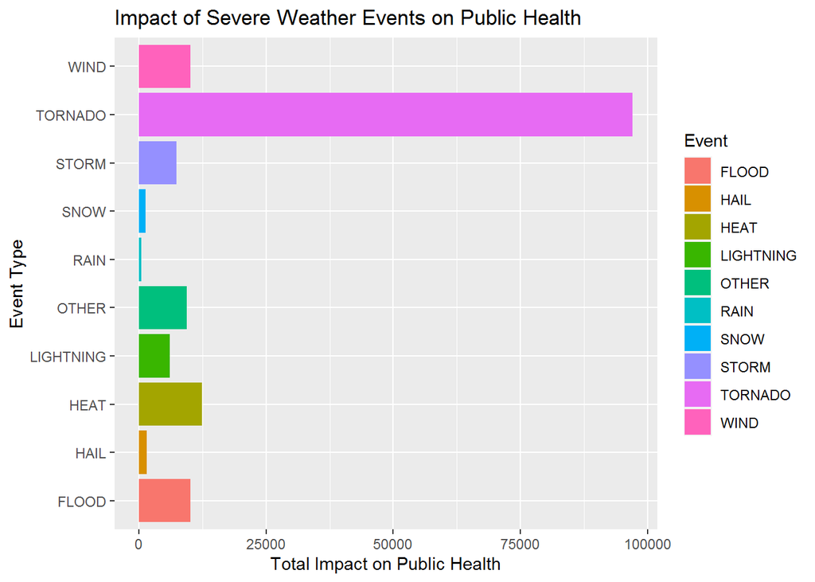

```r
# Loading the ggplot2 package
library(ggplot2)

# Plot for health impact
ggplot(data = event_type_health_total, aes(y = Event, x = impact_on_public_health, fill = Event)) + geom_bar(stat = "identity") + xlab("Total Impact on Public Health") + ylab("Event Type") + ggtitle("Impact of Severe Weather Events on Public Health")
```

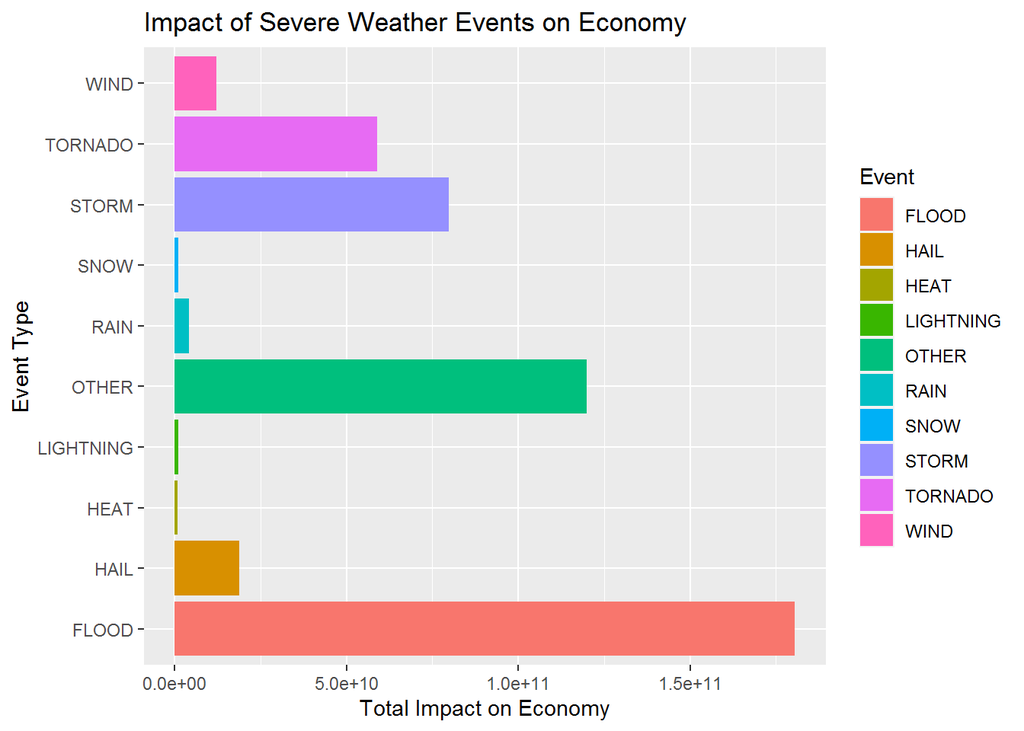

```r
# Plot for economic impact
ggplot(data = event_type_economy, aes(y = Event, x = impact_on_economy, fill = Event)) + geom_bar(stat = "identity") + xlab("Total Impact on Economy") + ylab("Event Type") + ggtitle("Impact of Severe Weather Events on Economy")
```

## Summary

Based on the results of the bar plots, the highest severe weather events that adversly impacts public health are **Tornados** and the economy are **Floods**.